# NS01: Binary choice vs. strength-of-preference

C E R Edmunds

20-02-2019

# Results

## Exclusions

As preregistered, we excluded participants on the basis of time on task. Time on task was operationalized as the proportion of time during the trial where participants were fixating on either the pictures or the response scale. We then plotted boxplots and histograms of the mean proportion for each participant to determine where a natural break point would be (and to see if any outliers were detected).

### Binary task

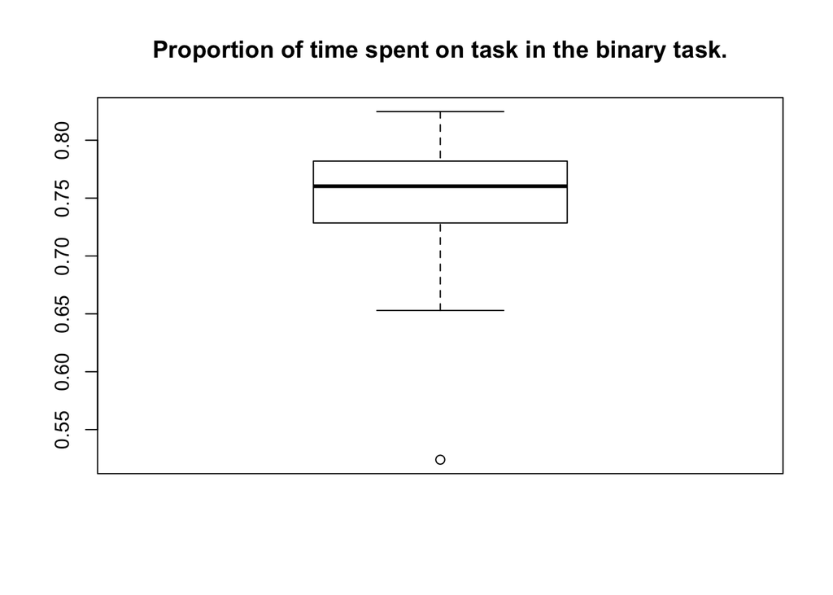

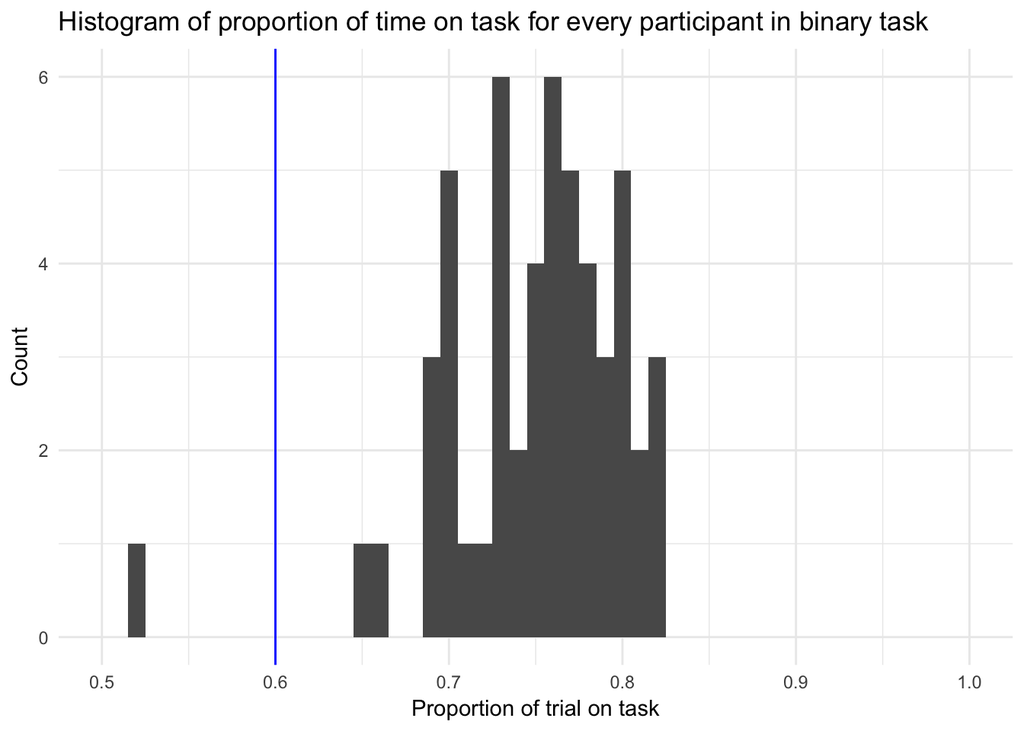

As can be seen from the boxplot and histogram, there was only one participant found to be an outlier (less than the first quartiler minus 1.5 times the interquartile range) in terms of time spent on task in the binary task.

### Continuous task

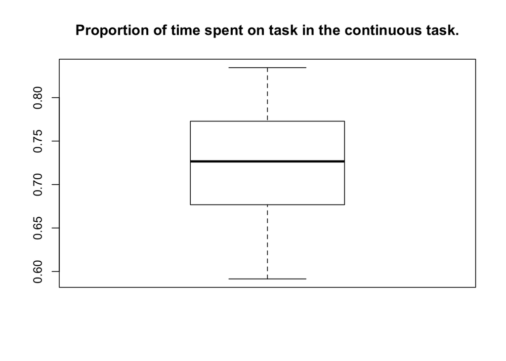

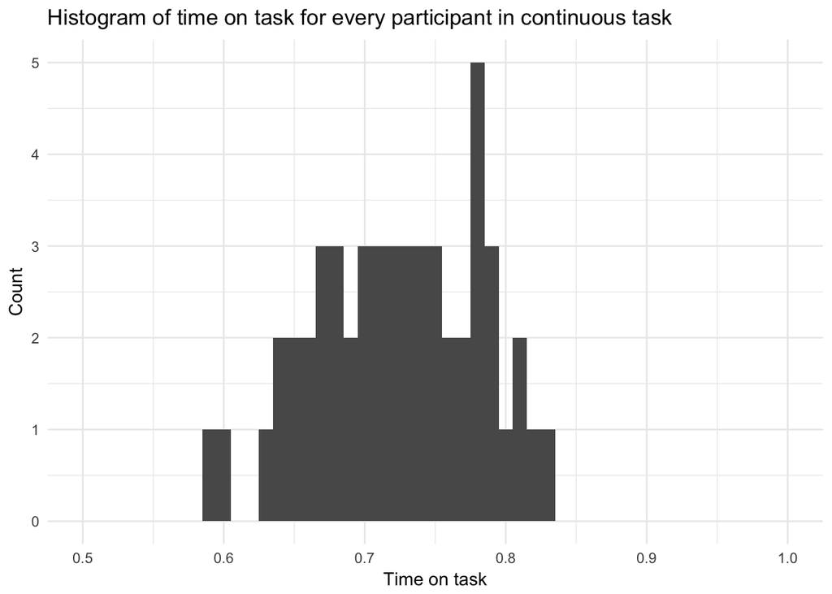

As can be seen from the boxplot and histogram, there were no participants found to be outliers in the continuous task.

Therefore, we excluded 1 participants, resulting in 52 remaining participants, who completed all tasks.

### Reaction times

Additionally, we excluded all trials with reaction times less than 200ms and trials where the reaction time is 3 standard deviations above the mean reaction time across all task trials (i.e. not including the liking rating task).

This resulted in excluding 2.04% of trials in the continuous task, and 1.23% of trials in binary task. The maximum number of trials excluded for a single participant was 15% across the two tasks.

## Analysis

So, we were interested in whether the interaction effect was greater in the continuous task or in the binary task.

One intuition was that participants might take longer to think in the continuous task than in the binary task and by taking longer to consider their choices, we might get different choices?

```r
rt <- lmer(rt ~ attention.difference*value.difference*task +
             (1 + attention.difference*value.difference||participantNo),
          data=data[task!="valuation"], REML=F, control=lmerControl(optimizer="Nelder_Mead"))
```

```
## boundary (singular) fit: see ?isSingular
```

```r
summary(rt)
summary(rePCA(rt)) # 2/4 components have variance greater than 1%

# Removing components with 0 variance: value.difference
rt1 <- lmer(rt ~ attention.difference*value.difference*task +
             (1 + attention.difference*value.difference - value.difference||participantNo),
          data=data[task!="valuation"], REML=F, control=lmerControl(optimizer="Nelder_Mead"))
summary(rt1)
summary(rePCA(rt1)) # 2/3 have variance>1%
anova(rt, rt1) # N.s. prefer rt1

# Remove components with smallest variance: interaction
rt2 <- lmer(rt ~ attention.difference*value.difference*task +
             (1 + attention.difference ||participantNo),
          data=data[task!="valuation"], REML=F, control=lmerControl(optimizer="Nelder_Mead"))
summary(rt2)
anova(rt1, rt2) # N.s. prefer rt2

rt3 <- lmer(rt ~ attention.difference*value.difference*task +
             (1|participantNo),
          data=data[task!="valuation"], REML=F, control=lmerControl(optimizer="Nelder_Mead"))
summary(rt3)
anova(rt2, rt3) # N.s prefer rt3

rt4 <- lm(rt ~ attention.difference*value.difference*task ,
          data=data[task!="valuation"])
summary(rt4)
anova(rt3, rt4) # Sig: prefer rt3
```

### Choice

Another might be that choice was affected by task.

```r
full <- glmer(recodedResponse ~ attention.difference*value.difference*task +
                (1 + attention.difference*value.difference||participantNo),
              data=data[task!="valuation",], family="binomial",
              control=glmerControl(optimizer="Nelder_Mead"))
summary(full)
summary(rePCA(full)) # 2/4 components have variance>1%

# Removed component with smallest variance (interaction term)
choice1 <- glmer(recodedResponse ~ attention.difference*value.difference*task +
                (1 + attention.difference + value.difference||participantNo),
              data=data[task!="valuation",], family="binomial",
              control=glmerControl(optimizer="Nelder_Mead"))
summary(choice1)
anova(full, choice1) # N.s so prefer choice1

choice2 <- glmer(recodedResponse ~ attention.difference*value.difference*task +
                (1 + attention.difference||participantNo),
              data=data[task!="valuation",], family="binomial",
              control=glmerControl(optimizer="Nelder_Mead"))
summary(choice2)
anova(choice2, choice1) # Sig so prefer choice1

choice3 <- glmer(recodedResponse ~ attention.difference*value.difference*task +
                (1 + value.difference||participantNo),
              data=data[task!="valuation",], family="binomial",
              control=glmerControl(optimizer="Nelder_Mead"))
summary(choice3)
anova(choice3, choice1) # Sig so prefer choice1
```

```r
choice1 <- glmer(recodedResponse ~ attention.difference*value.difference*task +
                (1 + attention.difference + value.difference||participantNo),
              data=data[task!="valuation",], family="binomial",
              control=glmerControl(optimizer="Nelder_Mead"))
summary(choice1)
```

```
## Generalized linear mixed model fit by maximum likelihood (Laplace
##   Approximation) [glmerMod]
##  Family: binomial  ( logit )
## Formula:
## recodedResponse ~ attention.difference * value.difference * task +
##     (1 + attention.difference + value.difference || participantNo)
##    Data: data[task != "valuation", ]
## Control: glmerControl(optimizer = "Nelder_Mead")
##
##      AIC      BIC   logLik deviance df.resid
##   3785.9   3857.9  -1882.0   3763.9     5104
##
## Scaled residuals:
##     Min      1Q  Median      3Q     Max
## -8.2768 -0.3811 -0.0420  0.3764 13.0684
##
## Random effects:
##  Groups          Name                 Variance Std.Dev.
##  participantNo   (Intercept)          0.05274  0.2296
##  participantNo.1 attention.difference 5.47624  2.3401
##  participantNo.2 value.difference     0.11155  0.3340
## Number of obs: 5115, groups:  participantNo, 52
##
## Fixed effects:
##                                                      Estimate Std. Error
## (Intercept)                                           0.01743    0.06761
## attention.difference                                  5.67674    0.44030
## value.difference                                      0.89135    0.06244
## taskcontinuous                                       -0.01329    0.08423
## attention.difference:value.difference                 0.06007    0.17389
## attention.difference:taskcontinuous                   0.57393    0.41618
## value.difference:taskcontinuous                       0.02216    0.05396
## attention.difference:value.difference:taskcontinuous -0.11204    0.25837
##                                                      z value Pr(>|z|)
## (Intercept)                                            0.258    0.797
## attention.difference                                  12.893   <2e-16 ***
## value.difference                                      14.276   <2e-16 ***
## taskcontinuous                                        -0.158    0.875
## attention.difference:value.difference                  0.345    0.730
## attention.difference:taskcontinuous                    1.379    0.168
## value.difference:taskcontinuous                        0.411    0.681
## attention.difference:value.difference:taskcontinuous  -0.434    0.665
## ---
## Signif. codes:  0 '***' 0.001 '**' 0.01 '*' 0.05 '.' 0.1 ' ' 1
##
## Correlation of Fixed Effects:
##             (Intr) attnt. vl.dff tskcnt att.:. attn.: vl.df:
## attntn.dffr  0.028
## valu.dffrnc  0.015  0.061
## taskcontins -0.612 -0.021 -0.009
## attntn.df:.  0.089  0.016  0.025 -0.070
## attntn.dff: -0.020 -0.421 -0.041  0.053 -0.028
## vl.dffrnc:t -0.012 -0.044 -0.418  0.004 -0.028  0.118
## attntn.d:.: -0.059 -0.009 -0.026  0.111 -0.670 -0.031  0.055
## convergence code: 0
## Model failed to converge with max|grad| = 0.00934545 (tol = 0.001, component 1)
```

```r
choice2 <- glmer(recodedResponse ~ attention.difference*value.difference +
                (1 + attention.difference + value.difference||participantNo),
              data=data[task!="valuation",], family="binomial",
              control=glmerControl(optimizer="Nelder_Mead"))
summary(choice2)
```

```
## Generalized linear mixed model fit by maximum likelihood (Laplace
##   Approximation) [glmerMod]
##  Family: binomial  ( logit )
## Formula: recodedResponse ~ attention.difference * value.difference + (1 +
##     attention.difference + value.difference || participantNo)
##    Data: data[task != "valuation", ]
## Control: glmerControl(optimizer = "Nelder_Mead")
##
##      AIC      BIC   logLik deviance df.resid
##   3780.0   3825.8  -1883.0   3766.0     5108
##
## Scaled residuals:
##     Min      1Q  Median      3Q     Max
## -8.2871 -0.3779 -0.0418  0.3763 11.2443
##
## Random effects:
##  Groups          Name                 Variance Std.Dev.
##  participantNo   (Intercept)          0.0518   0.2276
##  participantNo.1 attention.difference 5.5254   2.3506
##  participantNo.2 value.difference     0.1115   0.3340
## Number of obs: 5115, groups:  participantNo, 52
##
## Fixed effects:
##                                       Estimate Std. Error z value Pr(>|z|)
## (Intercept)                           0.009662   0.053290   0.181    0.856
## attention.difference                  5.938762   0.400668  14.822   <2e-16
## value.difference                      0.901925   0.056708  15.905   <2e-16
## attention.difference:value.difference 0.017726   0.129179   0.137    0.891
##
## (Intercept)
## attention.difference                  ***
## value.difference                      ***
## attention.difference:value.difference
## ---
## Signif. codes:  0 '***' 0.001 '**' 0.01 '*' 0.05 '.' 0.1 ' ' 1
##
## Correlation of Fixed Effects:
##             (Intr) attnt. vl.dff
## attntn.dffr  0.029
## valu.dffrnc  0.008  0.056
## attntn.df:.  0.091 -0.017  0.019
```

```r
anova(choice2, choice1) # N.s so prefer choice2
```

|  | Df | AIC | BIC | logLik | deviance | Chisq | Chi Df | Pr(>Chisq) |
| --- | --- | --- | --- | --- | --- | --- | --- | --- |
| choice2 | 7 | 3780.007 | 3825.786 | -1883.003 | 3766.007 | NA | NA | NA |
| choice1 | 11 | 3785.949 | 3857.888 | -1881.974 | 3763.949 | 2.05784 | 4 | 0.7251213 |

```r
choice3 <- glmer(recodedResponse ~ attention.difference + value.difference +
                (1 + attention.difference + value.difference||participantNo),
              data=data[task!="valuation",], family="binomial",
              control=glmerControl(optimizer="Nelder_Mead"))
summary(choice3)
```

```
## Generalized linear mixed model fit by maximum likelihood (Laplace
##   Approximation) [glmerMod]
##  Family: binomial  ( logit )
## Formula: recodedResponse ~ attention.difference + value.difference + (1 +
##     attention.difference + value.difference || participantNo)
##    Data: data[task != "valuation", ]
## Control: glmerControl(optimizer = "Nelder_Mead")
##
##      AIC      BIC   logLik deviance df.resid
##   3778.0   3817.3  -1883.0   3766.0     5109
##
## Scaled residuals:
##     Min      1Q  Median      3Q     Max
## -8.2152 -0.3778 -0.0417  0.3761 11.3764
##
## Random effects:
##  Groups          Name                 Variance Std.Dev.
##  participantNo   (Intercept)          0.05187  0.2277
##  participantNo.1 attention.difference 5.52529  2.3506
##  participantNo.2 value.difference     0.11155  0.3340
## Number of obs: 5115, groups:  participantNo, 52
##
## Fixed effects:
##                      Estimate Std. Error z value Pr(>|z|)
## (Intercept)           0.00894    0.05308   0.168    0.866
## attention.difference  5.93973    0.40065  14.825   <2e-16 ***
## value.difference      0.90179    0.05670  15.905   <2e-16 ***
## ---
## Signif. codes:  0 '***' 0.001 '**' 0.01 '*' 0.05 '.' 0.1 ' ' 1
##
## Correlation of Fixed Effects:
##             (Intr) attnt.
## attntn.dffr 0.030
## valu.dffrnc 0.006  0.056
```

```r
anova(choice2, choice3) # N.s so prefer choice3
```

|  | Df | AIC | BIC | logLik | deviance | Chisq | Chi Df | Pr(>Chisq) |
| --- | --- | --- | --- | --- | --- | --- | --- | --- |
| choice3 | 6 | 3778.025 | 3817.264 | -1883.012 | 3766.025 | NA | NA | NA |
| choice2 | 7 | 3780.007 | 3825.786 | -1883.003 | 3766.007 | 0.01800299 | 1 | 0.893264 |

```r
# No interaction and no effect of task
```

```r
binary.full <- glmer(response ~ attention.difference*value.difference +
                       (1 + attention.difference*value.difference|| participantNo),
                     family="binomial", data=data[task=="binary",])
summary(binary.full)
```

```
## Generalized linear mixed model fit by maximum likelihood (Laplace
##   Approximation) [glmerMod]
##  Family: binomial  ( logit )
## Formula:
## response ~ attention.difference * value.difference + (1 + attention.difference *
##     value.difference || participantNo)
##    Data: data[task == "binary", ]
##
##      AIC      BIC   logLik deviance df.resid
##   1923.4   1970.2   -953.7   1907.4     2560
##
## Scaled residuals:
##     Min      1Q  Median      3Q     Max
## -5.4467 -0.3770 -0.0415  0.3695  6.4872
##
## Random effects:
##  Groups          Name                                  Variance  Std.Dev.
##  participantNo   (Intercept)                           4.709e-02 0.21700
##  participantNo.1 attention.difference                  7.097e+00 2.66396
##  participantNo.2 value.difference                      1.598e-01 0.39980
##  participantNo.3 attention.difference:value.difference 8.410e-08 0.00029
## Number of obs: 2568, groups:  participantNo, 52
##
## Fixed effects:
##                                       Estimate Std. Error z value Pr(>|z|)
## (Intercept)                            0.02230    0.06874   0.324    0.746
## attention.difference                   5.86179    0.50266  11.661   <2e-16
## value.difference                       0.94526    0.07534  12.547   <2e-16
## attention.difference:value.difference  0.05310    0.17986   0.295    0.768
##
## (Intercept)
## attention.difference                  ***
## value.difference                      ***
## attention.difference:value.difference
## ---
## Signif. codes:  0 '***' 0.001 '**' 0.01 '*' 0.05 '.' 0.1 ' ' 1
##
## Correlation of Fixed Effects:
##             (Intr) attnt. vl.dff
## attntn.dffr 0.034
## valu.dffrnc 0.019  0.095
## attntn.df:. 0.083  0.011  0.017
```

```r
continuous.full <- glmer(recodedResponse ~ attention.difference*value.difference +
                       (1 + attention.difference*value.difference|| participantNo),
                     family="binomial", data=data[task=="continuous",])
summary(continuous.full)
```

```
## Generalized linear mixed model fit by maximum likelihood (Laplace
##   Approximation) [glmerMod]
##  Family: binomial  ( logit )
## Formula: recodedResponse ~ attention.difference * value.difference + (1 +
##     attention.difference * value.difference || participantNo)
##    Data: data[task == "continuous", ]
##
##      AIC      BIC   logLik deviance df.resid
##   1898.6   1945.3   -941.3   1882.6     2539
##
## Scaled residuals:
##     Min      1Q  Median      3Q     Max
## -7.7933 -0.3850 -0.0390  0.3557 10.0295
##
## Random effects:
##  Groups          Name                                  Variance Std.Dev.
##  participantNo   (Intercept)                           0.09555  0.3091
##  participantNo.1 attention.difference                  6.17968  2.4859
##  participantNo.2 value.difference                      0.07244  0.2691
##  participantNo.3 attention.difference:value.difference 0.20943  0.4576
## Number of obs: 2547, groups:  participantNo, 52
##
## Fixed effects:
##                                        Estimate Std. Error z value
## (Intercept)                           -0.005194   0.075729  -0.069
## attention.difference                   6.461078   0.508830  12.698
## value.difference                       0.886444   0.061164  14.493
## attention.difference:value.difference -0.032347   0.213701  -0.151
##                                       Pr(>|z|)
## (Intercept)                              0.945
## attention.difference                    <2e-16 ***
## value.difference                        <2e-16 ***
## attention.difference:value.difference    0.880
## ---
## Signif. codes:  0 '***' 0.001 '**' 0.01 '*' 0.05 '.' 0.1 ' ' 1
##
## Correlation of Fixed Effects:
##             (Intr) attnt. vl.dff
## attntn.dffr  0.038
## valu.dffrnc  0.001  0.136
## attntn.df:.  0.096 -0.050  0.035
```

A final intuition might be that participants were more accurate in the continuous task than the binary task.

### Analysing continuous task more fully

```r
# continuous.full <- lmer(response ~ attention.difference*value.difference +
#                         (1 + attention.difference*value.difference|| participantNo),
#                         data=data[task=="continuous",], glmerControl(optCtrl=list(maxfun=1e6)))
# summary(continuous.full)
```

# Notes

## Thoughts

- speed/accuracy trade off and it’s relationship between interaction vs. not.

# To do

- full interaction model to show between task effect
- inverse-U relationship between value and rt? in rating tasks.

# To double check: you need to plot attention against value for the different quintiles, then plot the models for each person over top.

To get the glm model fits for each person, it’s something like:

fixations[task==“binary”, .(model=glm(response ~ attention.difference*value.difference, data=.SD)), by=.(participantNo)]

or

lmList

Help from Naomi :) lfe package; felm